# Three Popular Optimization Methods and Their Applications on Log-likelihood Function and The MaxLik Package in R

Xiran Wang

xiranwangwork@gamil.com

Department of Statsitics, University of South Carolina

12/15/2019

## Project Introduction

The maximum likelihood method is one of the most important techniques in statistics. maximum Likelihood method is frequently used in many research fields. Not surprisingly, there are several popular statistical packages that include ready-made routines for maximum likelihood estimations. Most of them can’t offer users flexibility when they want to estimate non-standard models or develop new estimators. However, “maxLik” in R is one exception. This package includes the framework for simplifying the estimation, allowing the user to easily choose between a number of optimization algorithms, different ways of calculating variance-covariance matrices, and easily reporting the results. There three major optimization methods are implemented in “maxLik” package, which are they are Newton Raphson (N-R) method, Berndt-Hall-Hall-Hausman (BHHH) method and Nelder-Mead (N-M).

In this project, In the first main part, the usage of the “maxLik” package will be demonstrated in a detailed version. Then, in the second part, this project will focus on illustrating and evaluating Newton Raphson (N-R) method, Berndt-Hall-Hall-Hausman (BHHH) method, and Nelder-Mead (N-M) method, three optimization methods on estimating maximum likelihood estimators since they are three major optimization methods that are incorporated in “maxLik” package. Furthermore, the comparison of the performance of “maxLik” on estimating MLE giving different optimizations methods will be displayed.

## Part I: MaxLik Implementation

### 1. Basic useage

In this section, the functionality of the maxLik function will be presented. Log-likelihood is the target function in this project, and more specifically, normal(mu=1,sd=2) log-likelihood function will be used in all evaluations and comparisons. Furthermore, some important functionalities will be used and evaluated, evaluation and comparison will mainly focus on estimations of coefficients, variance/ covariance,log-likelihood-value, etc. The following shows the maxLik function in R.

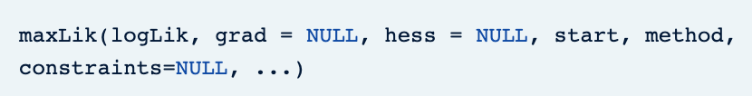

maxLik funtion in R

In this project, all simulations(x’s) are from normal distribution with mean = 1 sd = 2. The following are the probability density function, likelihood, and log-likelihood of the standard normal distribution:
$$f(x_i) =\frac{1}{\sigma \sqrt{2\pi}}\exp\left(-\frac{(x_i-\mu)^2}{2\sigma^2}\right)$$

$$L(x; \mu,\sigma) =\prod_{i=1}^{N} \frac{1}{ \sigma \sqrt{2\pi} } exp(-\frac{(x_i-\mu)^2}{2\sigma^2})$$

$$log(L(x; \mu,\sigma) ) =-\frac{1}{2}Nlog(2\pi)-Nlog(\sigma)-\frac{1}{2}\sum_{i=1}^{N}\frac{(x_i-\mu)^2}{\sigma^2}$$

For maxLik in the R, the most basic usage of maxLik command is displayed. In addition, the log-likelihood function specified, which provides more reliability. From the results, the maxLik can provide the log-Likelihood value, MLEs, as well as the standard error if the user states. The calculation logic behind this basic maxLik command will be also displayed in the following. In the end, based on the comparison result, the MEL for both mean and standard deviation are the same.

From theoretical maximum likelihood estimation method:
$$\mu =\frac{\sum_{i=1}^N x_i}{N}\ \ \ \ \ \sigma =\sqrt{ \frac{ \sum_{i=1}^N(X_i-\mu)^2 }{N}}$$
Estimation for $\mu$ and $\sigma$ from the random simulations(n=100):

```r
mean(x)
```

```
## [1] 0.9823451
```

```r
sqrt( sum( ( x-mean(x) )^2 ) /length(x) )
```

```
## [1] 1.912974
```

Estimation for $\mu$ and $\sigma$ from maxLik:

```r
logLikFun <- function(param) {
  mu <- param[1]
  sigma <- param[2]
  sum(dnorm(x, mean = mu, sd = sigma, log = TRUE)) }

mle <- maxLik(logLik = logLikFun, start = c(mu = 0, sigma = 1))
summary(mle)
```

```
## --------------------------------------------
## Maximum Likelihood estimation
## Newton-Raphson maximisation, 7 iterations
## Return code 1: gradient close to zero
## Log-Likelihood: -206.7598
## 2  free parameters
## Estimates:
##       Estimate Std. error t value Pr(> t)
## mu      0.9823     0.1912   5.137 2.8e-07 ***
## sigma   1.9130     0.1353  14.142 < 2e-16 ***
## ---
## Signif. codes:  0 '***' 0.001 '**' 0.01 '*' 0.05 '.' 0.1 ' ' 1
## --------------------------------------------
```

The comparison result shows that the estimations for $\mu$ and $\sigma$ are exactly the same when they get calculated directly from the simulation or maxLik.

```r
all.equal(coef(mle), c(mean(x), sqrt(sum((x - mean(x))^2)/100)), check.attributes = FALSE)
```

```
## [1] TRUE
```

### 2. Basic usage with analytical gradients

In the most basic usage case for maxLik, no analytical gradients are provided. For simple cases, the maxLik can calculate them for users, but the numerical derivatives may be costly to compute.
$$\frac{ \partial \log( L(x,\mu,\sigma))}{\partial \mu } = \sum_{i=1}^{N} \frac{ (x_i-\mu)}{\sigma^2}$$

$$\frac{ \partial \log( L(x,\mu,\sigma))}{\partial \sigma } =-\frac{N}{\sigma}+ \sum_{i=1}^{N} \frac{(x_i-\mu)^2}{\sigma^3}$$

The maxLik output when analytical gradients are provided:

```r
logLikGrad <- function(param) {
  mu <- param[1]
  sigma <- param[2]
  N <- length(x)
  logLikGradValues <- numeric(2)
  logLikGradValues[1] <- sum((x - mu)/sigma^2)
  logLikGradValues[2] <- -N/sigma + sum((x - mu)^2/sigma^3)
  return(logLikGradValues)
   }
mleGrad <- maxLik(logLik = logLikFun,
                  grad = logLikGrad, start = c(mu = 0, sigma = 1))
summary(mleGrad)
```

```
## --------------------------------------------
## Maximum Likelihood estimation
## Newton-Raphson maximisation, 7 iterations
## Return code 1: gradient close to zero
## Log-Likelihood: -206.7598
## 2  free parameters
## Estimates:
##       Estimate Std. error t value  Pr(> t)
## mu      0.9823     0.1913   5.135 2.82e-07 ***
## sigma   1.9130     0.1353  14.142  < 2e-16 ***
## ---
## Signif. codes:  0 '***' 0.001 '**' 0.01 '*' 0.05 '.' 0.1 ' ' 1
## --------------------------------------------
```

Providing analytical gradients has no (relevant) effect on the estimates but their covariance matrix and standard errors are slightly different. Because the Hessians are calculated numerically by the function numericHessian based on the analytical gradients provided by users. the logical comparison shows “Ture” of user-specified Hessian with analytic gradients vs. only analytic gradient.

```r
all.equal(logLik(mleGrad), logLik(mle))
```

```
## [1] TRUE
```

```r
all.equal(coef(mleGrad), coef(mle))
```

```
## [1] TRUE
```

```r
all.equal(vcov(mleGrad), vcov(mle)) #abs(a-b)/abs(a)
```

```
## [1] "Mean relative difference: 0.001079409"
```

```r
vcov(mleGrad)
```

```
##                 mu        sigma
## mu    3.659469e-02 2.288827e-12
## sigma 2.288827e-12 1.829735e-02
```

```r
vcov(mle)
```

```
##                  mu         sigma
## mu     3.657421e-02 -1.901935e-05
## sigma -1.901935e-05  1.829662e-02
```

### 3. Basic usage with analytical gradients and hessians

The hessain matrix for log-likelihood function for the normal distribution are:
$$\begin{align*}
\frac{ \partial^2 log( L(x,\mu,\sigma))}{\partial \mu \partial \mu }
&=-\frac{N}{\sigma^2}\\
\frac{ \partial^2 log( L(x,\mu,\sigma))}{\partial \mu \partial \sigma }
&=-2\sum_{i=1}^{N} \frac{ (x_i-\mu)}{\sigma^3} \\
\frac{\partial^2 log( L(x,\mu,\sigma))}{\partial \sigma \partial \sigma }
&=\frac{N}{\sigma^2}- 3\sum_{i=1}^{N} \frac{(x_i-\mu)^2}{\sigma^4} \\
\frac{\partial^2 log( L(x,\mu,\sigma))}{\partial\sigma\partial \mu }
&= -2\sum_{i=1}^{N} \frac{ (x_i-\mu)}{\sigma^3}
\end{align*}$$

The logLikHess below function shows how MaxLik calculates the hessian matrix numerically. In this situation, the maxLik function is incorporated into the hessian matrix.

```r
logLikHess <- function(param) {
  mu <- param[1]
  sigma <- param[2]
  N <- length(x)
  logLikHessValues <- matrix(0, nrow = 2, ncol = 2)
  logLikHessValues[1, 1] <- -N/sigma^2
  logLikHessValues[1, 2] <- -2 * sum((x - mu)/sigma^3)
  logLikHessValues[2, 1] <- logLikHessValues[1, 2]
  logLikHessValues[2, 2] <- N/sigma^2 - 3 * sum((x - mu)^2/sigma^4)
  return(logLikHessValues)
}

mleHess <- maxLik(logLik = logLikFun, grad = logLikGrad,
                    hess = logLikHess, start = c(mu = 0, sigma = 1))
summary(mleHess)
```

```
## --------------------------------------------
## Maximum Likelihood estimation
## Newton-Raphson maximisation, 7 iterations
## Return code 1: gradient close to zero
## Log-Likelihood: -206.7598
## 2  free parameters
## Estimates:
##       Estimate Std. error t value  Pr(> t)
## mu      0.9823     0.1913   5.135 2.82e-07 ***
## sigma   1.9130     0.1353  14.142  < 2e-16 ***
## ---
## Signif. codes:  0 '***' 0.001 '**' 0.01 '*' 0.05 '.' 0.1 ' ' 1
## --------------------------------------------
```

```r
all.equal(list(logLik(mleHess), coef(mleHess),
               vcov(mleHess)),list(logLik(mleGrad), coef(mleGrad), vcov(mleGrad)))
```

```
## [1] TRUE
```

After understanding how the specification of hessian and analytical ingredients in maxLik affects the estimation results, next, the project focuses on comparisons of using different optimization methods used in maxLik.

## Part II: Three Numerical Optimization Methods

Want to maximize or minimize the (possibly nonlinear) objective function f($\theta$), which is usually log-likelihood function. For general 3 parts to numerical search algorithms: (1) obtaining initial starting values for the parameters, say $\theta_0$ (2) updating the candidate value for $\theta$ (3) determining when the optimum has been reached, and it is where the optimization method is applied.

### 1. Newtown Raphson(N-R)

#### a. Introduction

Let g(u) to be a target function need found its roots by performing the Newtown Raphson algorithm can be described as follows:
$$u_{n+1} = u_n -\frac{g(u_n)}{g^\prime(u_n)}$$
Samilarly, when g’(u) is the target function, the Newtown Raphson algorithm becomes to be:
$$u_{n+1} = u_n -\frac{g'(u_n)}{g''(u_n)}$$
To better address the common calculation results for log-likelihood later, here, the multi-dimension Newtown Raphson algorithm is introduced in the following:

$$u^{(n+1)} =u^{(n)} -[Hg(u^{(n)}) ]^{-1} \nabla g( u^{(n)})$$
Where
$$\nabla g(u) = \begin{bmatrix} \frac{\partial g(u)}{\partial u_1} & \frac{\partial g(u)}{\partial u_2} & ... \frac{\partial g(u)}{\partial u_n} \end{bmatrix}^T$$
and
$$Hg(u) =
\frac{d \mathbf{g}}{d \mathbf{u}}
=
\left[ \frac{\partial \mathbf{g}}{\partial u_1}
\cdots \frac{\partial \mathbf{g}}{\partial u_n} \right]
=
\begin{bmatrix}
\frac{\partial^2 g(u)}{\partial u_1^2}
\frac{\partial^2 g(u)}{\partial u_1 \partial u_2} & \cdots &
\frac{\partial^2 g(u)}{\partial u_1 \partial u_n} \\
\frac{\partial^2 g(u)}{\partial u_2 \partial u_2}
\frac{\partial^2 g(u)}{\partial u_2 \partial u_2} & \cdots &
\frac{\partial^2 g(u)}{\partial u_2 \partial u_n} \\
\vdots & \ddots & \vdots \\
\frac{\partial g(u)}{\partial u_n \partial u_1}
\frac{\partial^2 g(u)}{\partial u_n \partial u_2} & \cdots &
\frac{\partial g(u)}{\partial u_n^2}
\end{bmatrix}$$

#### b. Application on the simulations

Again, here x is simulated form normal distribution with mean = 1 and sd = 2. The target function is the first derivative of log-likelihood function, which is $\nabla$g(x) in the following. The hessian matrix for the normal distribution is also showed below.

$$\nabla g(x) = \begin{bmatrix} \sum_{i=1}^{N} \frac{(x_i-\mu)}{\sigma^2},-\frac{N}{\sigma}+ \sum_{i=1}^{N} \frac{(x_i-\mu)^2}{\sigma^3} \end{bmatrix}^T$$

$$Hg(u)= \begin{bmatrix}-\frac{N}{\sigma^2} & -2 \sum_{i=1}^{N}\frac{ (x_i-\mu)}{\sigma^3} \\
-2 \sum_{i=1}^{N} \frac{ (x_i-\mu)}{\sigma^3}&\frac{N}{\sigma^2}- 3\sum_{i=1}^{N} \frac{(x_i-\mu)^2}{\sigma^4}\end{bmatrix}$$

```r
mleNR=maxLik(logLik = logLikFun, grad = logLikGrad,
                    hess = logLikHess, start = c(mu = 0, sigma = 1))
summary(mleNR)
```

```
## --------------------------------------------
## Maximum Likelihood estimation
## Newton-Raphson maximisation, 7 iterations
## Return code 1: gradient close to zero
## Log-Likelihood: -206.7598
## 2  free parameters
## Estimates:
##       Estimate Std. error t value  Pr(> t)
## mu      0.9823     0.1913   5.135 2.82e-07 ***
## sigma   1.9130     0.1353  14.142  < 2e-16 ***
## ---
## Signif. codes:  0 '***' 0.001 '**' 0.01 '*' 0.05 '.' 0.1 ' ' 1
## --------------------------------------------
```

### 2. Berndt-hall-hall-Hausman (BHHH)

#### a. Introduction

This algorithm follows the Newton-Raphson approach but replaces the negative of the Hessian ( $-Hg(u^{(n)})$ )by an approximation formed from the sum of the outer products of the gradient vectors for each observation’s contribution to the objective function. For least squares and log-likelihood functions, this approximation is asymptotically equivalent to the actual Hessian when evaluated at the parameter values which maximize the function.

$$u^{(n+1)} =u^{(n)} +[\nabla g( u^{(n)} ) \times (\nabla g( u^{(n)})^t ]^{-1} \nabla g( u^{(n)})$$
where
$$\nabla g(u) = \begin{bmatrix} \frac{\partial g(u)}{\partial u_1} & \frac{\partial g(u)}{\partial u_2} & ... \frac{\partial g(u)}{\partial u_n} \end{bmatrix}^T$$

#### b. Application on the simulations

$$\nabla g(x) = \begin{bmatrix} \sum_{i=1}^{N} \frac{ (x_i-\mu)}{\sigma^2}, -\frac{N}{\sigma}+ \sum_{i=1}^{N} \frac{(x_i-\mu)^2}{\sigma^3} \end{bmatrix} ^T$$

```r
mleBHHH <- maxLik(logLik = logLikFun, grad = logLikGradInd,
                  start = c(mu = 0, sigma = 1), method = "BHHH")
summary(mleBHHH)
```

```
## --------------------------------------------
## Maximum Likelihood estimation
## BHHH maximisation, 11 iterations
## Return code 2: successive function values within tolerance limit
## Log-Likelihood: -206.7598
## 2  free parameters
## Estimates:
##       Estimate Std. error t value  Pr(> t)
## mu      0.9823     0.1913   5.135 2.82e-07 ***
## sigma   1.9130     0.1445  13.235  < 2e-16 ***
## ---
## Signif. codes:  0 '***' 0.001 '**' 0.01 '*' 0.05 '.' 0.1 ' ' 1
## --------------------------------------------
```

#### Comparsion: N-R vs. BHHH

Based on the comparisons, the estimated parameters and the corresponding log-likelihood value are virtually identical to the NR estimates, the covariance matrix of the estimated parameters is slightly different. This is because the outer product approximation may differ from the derivative-based Hessian on finite samples.(Calzolari and Fiorentini 1993)

```r
all.equal(logLik(mleBHHH), logLik(mleNR))
```

```
## [1] TRUE
```

```r
all.equal(coef(mleBHHH), coef(mleNR))
```

```
## [1] "Mean relative difference: 2.1456e-06"
```

```r
all.equal(vcov(mleBHHH), vcov(mleNR))
```

```
## [1] "Mean relative difference: 0.04879283"
```

```r
vcov(mleBHHH)
```

```
##                  mu         sigma
## mu     0.0365957264 -0.0001098873
## sigma -0.0001098873  0.0208922627
```

```r
vcov(mleNR)
```

```
##                  mu         sigma
## mu     3.659469e-02 -4.803543e-13
## sigma -4.803543e-13  1.829735e-02
```

To have more understandings about where the differences come and why BHHH method works, it has to refer to asymptotic normality for MLEs:

Suppose $X_1,...,X_n$ are iid from $L(x|\theta)$ (log-likeliohood):
$$\sqrt n( \theta_{mle}-\theta) \xrightarrow{d}N(0,v(\theta))$$
as n $\to$ inf, where the asymptotic variance
$$v(\theta)=\frac{1}{nI_n(\theta)}$$
Knowing that $I_n(\theta)$, the Fisher Information based on n observations, is given by
$$I_n(\theta)=E_{\theta} \{\ { [\frac{\partial}{ \partial\theta}logL_n(X|\theta)]^2}\ \}=-E_\theta [ \ \frac{\partial^2} {\partial\theta^2}logL_n(X|\theta) \ ]$$

Variance Estimators for two methods:  
*Newtown Raphson:*

$$var(\theta)=-E[Hg(u^{(n)}) ]^{-1}\\$$

*BHHH:*
$$var(\theta)=E[\nabla g( u^{(n)} ) \times (\nabla g( u^{(n)})^t]^{-1}$$

Furthermore, The BHHH method is likely to have a slower convergence rate since the information matrix is only an approximation of the Hessian. This approximation can be quite bad, especially if $\theta_0$ is very far from the optimal value of $\theta$. NR has 7 iterations, given the same starting points for both of them. In addition, the NR method is computationally intensive as it requires to compute and invert the Hessian matrix at each step. Here, BHHH is less demanding as it requires only to compute the gradient of log-likelihood. In fact, in many applications, the information matrix has a single form and is much easier to compute. Moreover, for the BHHH method, provided the model is identifiable, the information matrix is always positive definite. Therefore, some of the convergence problems of the Newton-Raphson method may be avoided.

### 3. Nelder-Mead (N-M)

#### a. Introduction

The Nelder-Mead method uses a geometrical shape called a simplex as its ‘vehicle’ of sorts to search the domain. This is why the technique is also called the Simplex search method. In layman’s terms, a simplex is the n-dimensional version of a “triangle”. In the log-likelihood case, the dimension is 2. One iteration of the Nelder-Mead method consists of the following three steps:

- **Ordering**: determine the indices h,s,l of the worst, second worst and the best vertex, respectively, in the current working simplex S
  $$f_{h}=min_jf_j,\ \ \ f_s =min_{j\neq h} f_j,\ \ \ f_l =max_{j\neq h }f_j$$
- **Centroid**: Calculate the centroid c of the best side—this is the one opposite the worst vertex $x_h$, $c=\frac{1}{n}\sum_{j \neq h} x_j$
- **Transformation**: Compute the new working simplex from the current one. First, try to replace only the worst vertex $x_h$ with a better point by using reflection, expansion, or contraction with respect to the best side.Simplex transformations in the Nelder-Mead method are controlled by four parameters, which are $\alpha>0$, $0<\beta<1$, $\gamma>1$, $0<\delta<1$. For most of implementations, $\alpha=1$, $\beta=1/2$, $\gamma=2$, $delta=1/2$
  - Reflect:  
    Compute the reflection point $x_r=c+\alpha(c-x_h)$ and $f_r=f(x_r)$.  
    If $f_s\leq f_r$, accept $x_r$,terminate the iteration and move to the expansion interation.
  - Expand:  
    If $f_r>f_l$ compute the expansion point, $x_e=c+\gamma(x_r-c)$ and $f_e=f(x_e)$.  
    If $f_e>f_r$, accept $x_e$ and terminate the iteration and move to contraction interation.  
    Otherwise $f_e\leq f_r$, accept $x_r$, terminate the iteration and move to contraction interation.
  - Contraction: If $f_r\leq f_s$, compute the contraction point $x_c$ by using the better of the two points $x_h$ and $x_r$.
    - Outside:  
      If $f_h\leq f_r<f_s$, compute $x_c=c+\beta(x_r-c)$ and $f_c=f(x_c)$.  
      If $f_c\geq f_r$, accept $x_c$ and terminate the iteration.  
      Otherwise, perform a shrink transformation.
    - Inside:  
      If $f_h\geq f_r$, compute $x_c=c+\beta(x_h-c)$ and $f_c=f(x_c)$.  
      If $f_c>f_h$, accept $x_c$ and terminate the iteration.  
      Otherwise, perform a shrink transformation.
    - Shrink:  
      Compute n new vertices $x_j=x_l+\delta(x_j-x_l)$ and $f_j=f(x_j)$, for j=0,…,n, with $j\neq l$.  
      To be noticed, The shrink takes place when the contraction causes the reflected point to move away from the the peak instead of towards it. Further contractions are then useless. The action proposed contracts the simplex towards the highest point, and will eventually bring all points nearby the peak.

#### b. Application on the simulations

```r
mleNM <- maxLik(logLik = logLikFun, start = c(mu = 0,  sigma = 1), method = "NM")
summary(mleNM)
```

```
## --------------------------------------------
## Maximum Likelihood estimation
## Nelder-Mead maximization, 61 iterations
## Return code 0: successful convergence
## Log-Likelihood: -206.7598
## 2  free parameters
## Estimates:
##       Estimate Std. error t value  Pr(> t)
## mu      0.9825     0.1911    5.14 2.74e-07 ***
## sigma   1.9130     0.1352   14.15  < 2e-16 ***
## ---
## Signif. codes:  0 '***' 0.001 '**' 0.01 '*' 0.05 '.' 0.1 ' ' 1
## --------------------------------------------
```

```r
logLik(mleNM) - logLik(mleNR)
```

```
## [1] -5.709462e-07
## attr(,"df")
## [1] 2
```

```r
all.equal(coef(mleNM), coef(mleNR))
```

```
## [1] "Mean relative difference: 7.747375e-05"
```

```r
all.equal(vcov(mleNM), vcov(mleNR))
```

```
## [1] "Mean relative difference: 0.001944555"
```

### 4. Summary and simulation results for N-R, BHHH, and N-R

Estimations for 3 methods

|  | N-R | BHHH | N-M |
| --- | --- | --- | --- |
| Loglikeloood | -206.7597594 | -206.7597594 | -206.7597600 |
| Mu | 0.9823451 | 0.9823449 | 0.9825471 |
| Sigma | 1.9129739 | 1.9129799 | 1.9129516 |

Covariance matrix for 3 methods

|  | mu | sigma |
| --- | --- | --- |
| **N-R** |  |  |
| mu | 0.0365947 | 0.0000000 |
| sigma | 0.0000000 | 0.0182973 |
| **BHHH** |  |  |
| mu | 0.0365957 | -0.0001099 |
| sigma | -0.0001099 | 0.0208923 |
| **N-M** |  |  |
| mu | 0.0365362 | -0.0000190 |
| sigma | -0.0000190 | 0.0182871 |

- **N-R:**

*Advantages*:

1. Convergence rate is one of the fastest when it does converges.
2. The estimation is robust.

*Disadvantage*:

1. Require intensive consultation - it needs the function evaluation and then the derivative evaluation.
- **BHHH:**

*Advantages*:

1. Only needs 1st derivatives.
2. The outer product is necessarily positive definite.

*Disadvantage*:

1. Uses the hessian matrix approximation, it may provide a poor guide to the overall shape of the function when it is away from the maximum, so more iterations may be needed for convergence.
- **N-M:**

*Advantages*:

1. gives significant improvements in the first few iterations and quickly produces quite satisfactory results. It is very important in applications where each function evaluation is very expensive or time-consuming.
2. the method typically requires only one or two function evaluations per iteration.

*Disadvantage*:

1. the lack of convergence theory is often reflected in practice as a numerical breakdown of the algorithm, even for smooth and well-behaved functions.
2. the method can take an enormous amount of iterations with negligible improvement in function value, despite being nowhere near to a minimum.